# NLP Basics Hacker Hour

Archi Parekh

# NLP Basics Hacker Hour Demo

```r
library(rmarkdown)
library(knitr)
library(readr)
library(dplyr)
library(stringr)
library(tidyr)
library(tidytext)
library(ggplot2)
library(sotu)
library(quanteda)
library(SnowballC)
library(reshape2)
library(viridis)
```

### Preprocessing

Let’s analyze presidential inaugural speeches from the from the 2000s. First, I’ll demonstrate preprocessing on Biden’s inaugural speech.

```r
biden <- data_corpus_inaugural[59] %>% stack() %>% as_tibble()
colnames(biden) <- c("text", "title")
biden[["text"]]
```

```
## [1] "Chief Justice Roberts, Vice President Harris, Speaker Pelosi, Leader Schumer, Leader McConnell, Vice President Pence, distinguished guests, and my fellow Americans.\n\nThis is America's day.\n\nThis is democracy's day.\n\nA day of history and hope.\n\nOf renewal and resolve.\n\nThrough a cru…
```

There’s a lot of data here that we want to analyze. Let’s start off by separating the words in Biden’s inaugural speech. This is done using a function in tidytext called unnest_tokens.

```r
biden_words <- biden %>% unnest_tokens(word, text)
```

### Word Frequency Analysis

The easiest way to explore a speech is to see which words are used most frequently.

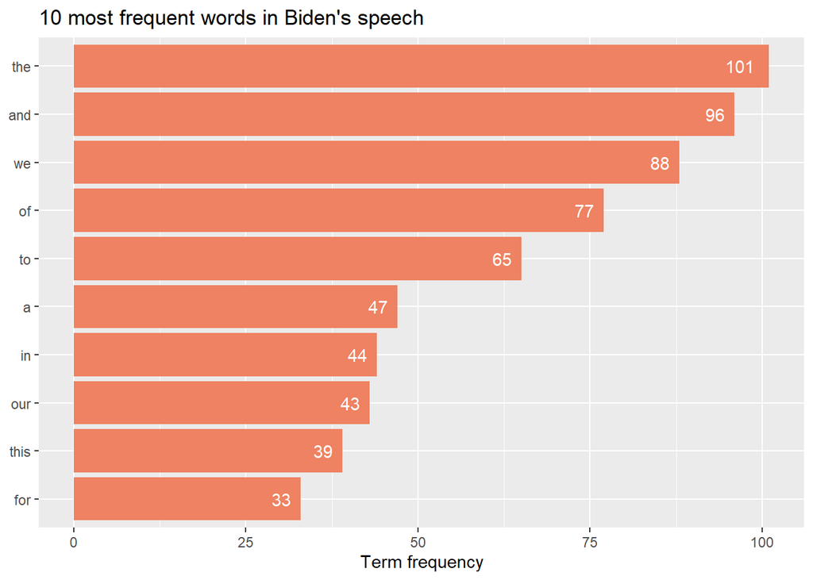

```r
biden_words %>%
  count(word, sort=TRUE) %>%
  slice(1:10) %>%
  mutate(word=reorder(word, n)) %>%
  ggplot(aes(n, word)) + geom_col(fill="salmon2") + geom_text(aes(label = n), hjust = 1.5, colour = "white") + labs(y = NULL, x = "Term frequency", title = paste("10 most frequent words in Biden's speech"))
```

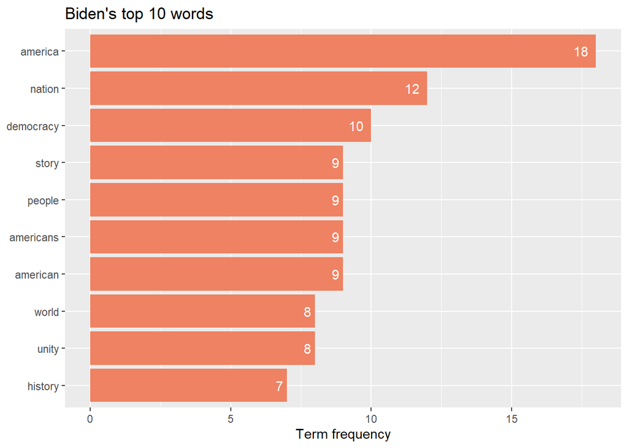

```r
biden_words <- biden_words %>% anti_join(stop_words)
biden_words_plot <- biden_words %>%
  count(word, sort=TRUE) %>%
  slice(1:10) %>%
  mutate(word=reorder(word, n)) %>%
  ggplot(aes(n, word)) + geom_col(fill="salmon2") + geom_text(aes(label = n), hjust = 1.5, colour = "white") + labs(y = NULL, x = "Term frequency", title = paste("Biden's top 10 words"))
biden_words_plot
```

Stemming is a way of combining common words like “democracy” and “democracies”

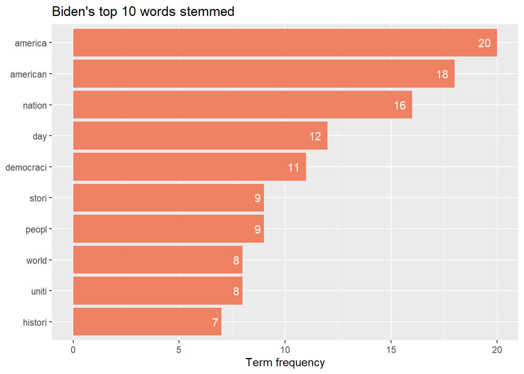

```r
biden_words_stemmed <- biden_words %>% mutate_at("word", funs(wordStem((.), language="en")))

biden_words_stemmed_plot <- biden_words_stemmed %>%
  count(word, sort=TRUE) %>%
  slice(1:10) %>%
  mutate(word=reorder(word, n)) %>%
  ggplot(aes(n, word)) + geom_col(fill="salmon2") + geom_text(aes(label = n), hjust = 1.5, colour = "white") + labs(y = NULL, x = "Term frequency", title = paste("Biden's top 10 words stemmed"))
biden_words_stemmed_plot
```

So far, we have used the bag of words approach to analyzing this speech. Let’s use bigrams and trigrams and see if that yields any interesting results.

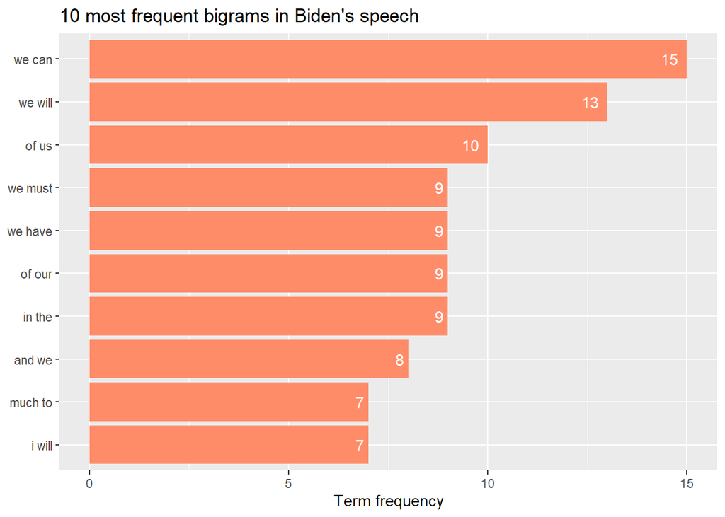

```r
biden_bigrams <- biden %>% unnest_tokens(word, text, token = "ngrams", n=2)
biden_bigrams %>%
  count(word, sort=TRUE) %>%
  slice(1:10) %>%
  mutate(word=reorder(word, n)) %>%
  ggplot(aes(n, word)) + geom_col(fill="salmon1") + geom_text(aes(label = n), hjust = 1.5, colour = "white") + labs(y = NULL, x = "Term frequency", title = paste("10 most frequent bigrams in Biden's speech"))
```

Out of curiosity, let’s see what trigrams are most frequent.

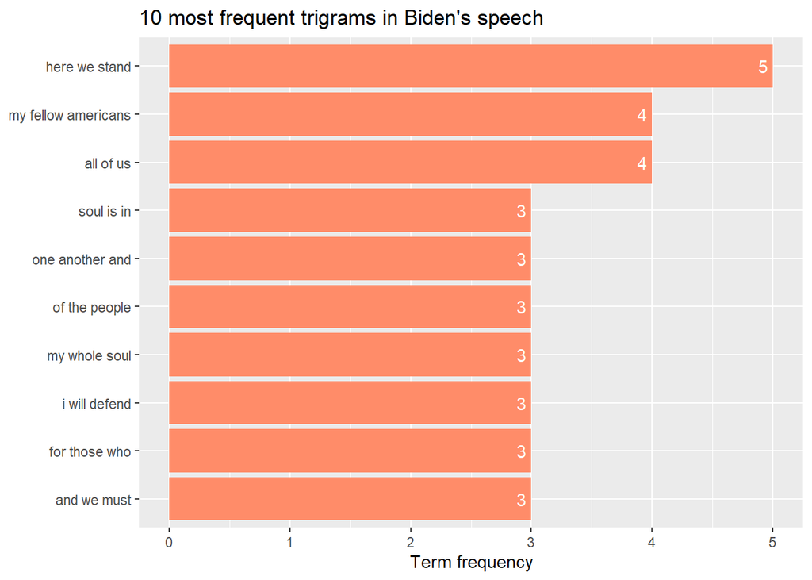

```r
biden %>%
  unnest_tokens(word, text, token = "ngrams", n=3) %>%
  count(word, sort=TRUE) %>%
  slice(1:10) %>%
  mutate(word=reorder(word, n)) %>%
  ggplot(aes(n, word)) + geom_col(fill="salmon1") + geom_text(aes(label = n), hjust = 1.5, colour = "white") + labs(y = NULL, x = "Term frequency", title = paste("10 most frequent trigrams in Biden's speech"))
```

I’m curious how Biden’s and Trump’s top 10 words compare.

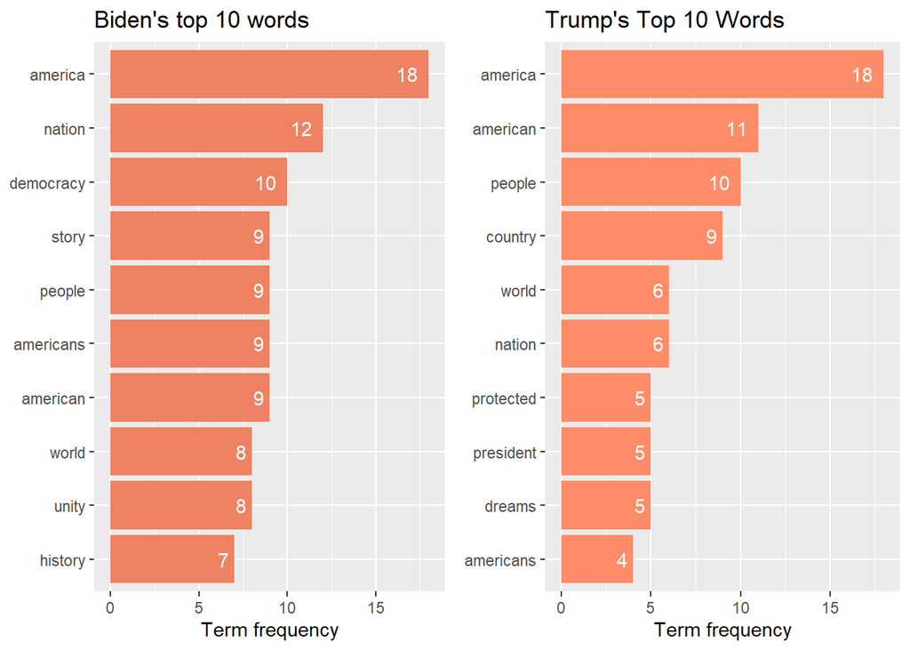

```r
trump_words_plot <- data_corpus_inaugural[58] %>%
  stack() %>%
  as_tibble() %>%
  unnest_tokens(word, values) %>%
  anti_join(stop_words) %>%
  count(word, sort=TRUE) %>%
  slice(1:10) %>%
  mutate(word=reorder(word, n)) %>%
  ggplot(aes(n, word)) + geom_col(fill="salmon1") + geom_text(aes(label = n), hjust = 1.5, colour = "white") + labs(y = NULL, x = "Term frequency", title = paste("Trump's Top 10 Words"))


require(gridExtra)
grid.arrange(biden_words_plot, trump_words_plot, ncol=2)
```

### Comparing Documents with TF-IDF and Cosine Similarity

Comparing word frequencies is just one way to compare documents. In this example, we see how words like america and americans are common to both speeches. We don’t really care about the frequency of “america” as much because it is a similarity. We would rather focus on the differences between the texts. To do this, we need to play around with the weights of the word frequencies relative to other documents in a corpus.

If that felt overwhelming, don’t worry. Tidy text has a function implementing all that math. Let’s see how similar inaugural speeches from Bush to Biden were.

```r
speech_data <- data_corpus_inaugural %>% tail() %>% stack() %>% as_tibble()
colnames(speech_data) <- c("text", "title")

speeches <- speech_data %>% unnest_tokens(word, text) %>% anti_join(stop_words) %>% count(title, word)

speech_tfidf <- speeches %>% bind_tf_idf(word, title, n)
```

Change the word below to explore different weights. If you try a word like “america” or “carry”, you will find that the tf-idf weight is 0. This is because it occurs in every single document in the corpus.

```r
speech_tfidf %>% filter(word == "afford")
```

```
## # A tibble: 3 x 6
##   title      word       n      tf   idf   tf_idf
##   <fct>      <chr>  <int>   <dbl> <dbl>    <dbl>
## 1 2001-Bush  afford     1 0.00168 0.693 0.00116
## 2 2009-Obama afford     2 0.00224 0.693 0.00156
## 3 2013-Obama afford     1 0.00122 0.693 0.000843
```

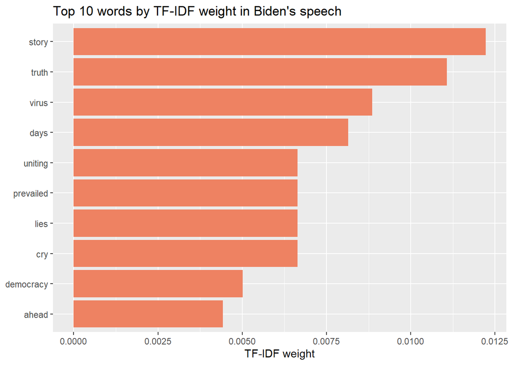

```r
speech_tfidf %>% filter(title == "2021-Biden") %>%
  arrange(desc(tf_idf)) %>%
  mutate(word = reorder(word, tf_idf)) %>%
  head(10) %>%
  ggplot(aes(tf_idf, word)) +
  geom_col(fill='salmon2') +
  labs(y = NULL, x='TF-IDF weight', title="Top 10 words by TF-IDF weight in Biden's speech")
```

See? Better words.

Now, let’s compare documents. So far, we have represented each document in the corpus as a vector. With some basic linear algebra knowledge, we can see that the closer a vector is to another, the more similar.

This is called cosine similarity.

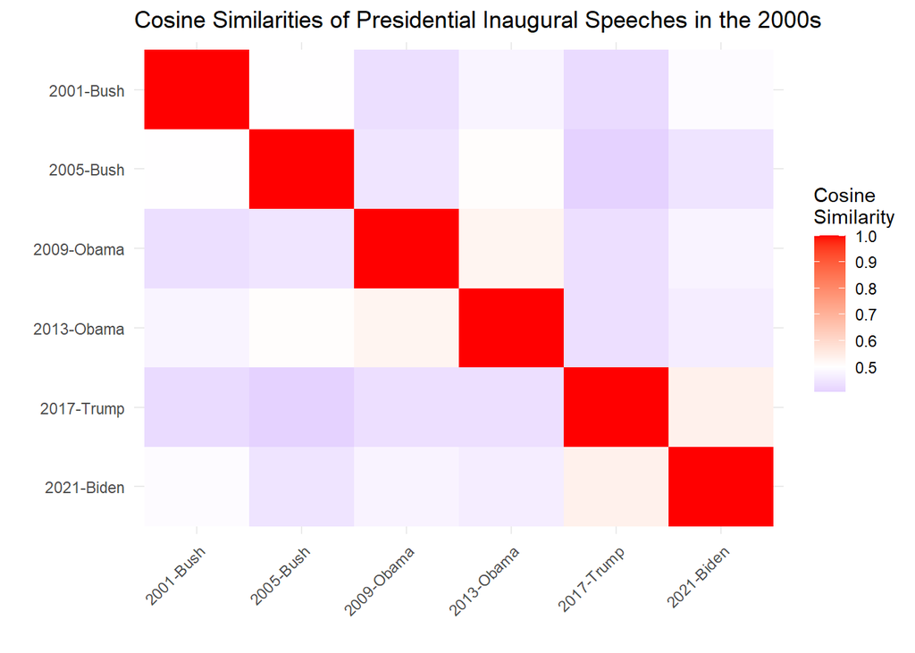

```r
tf_matrix <- speech_tfidf %>%
  cast_dtm(title, word, tf) %>%
  as.matrix()

# To calculate cosine similarity with matrices, normalize each column and multiply by transpose
# you can find a proof of why this works online.

normalize <- function(v) {
  return (v/sqrt(v %*% v))
}

for (i in 1:dim(tf_matrix)[1]) {
  tf_matrix[i,] <- normalize(tf_matrix[i,])
}


sims <- tf_matrix %*% t(tf_matrix)

data <- melt(sims)
colnames(data) <- c("speech.i", "speech.j", "similarity")

ggplot(data, aes(x = speech.j, y = speech.i, fill = similarity)) +
  geom_tile() +
  scale_fill_gradient2(low = "blue", high = "red", mid = "white",
   midpoint = 0.5, space = "Lab",
   name="Cosine\nSimilarity") +
  theme_minimal() +
  labs (x = "", y = "", title = "Cosine Similarities of Presidential Inaugural Speeches in the 2000s") +
  theme(axis.text.x = element_text(angle = 45, hjust = 1)) +
  ylim(rev(levels(data$speech.i))) +
  xlim(levels(data$speech.j))
```

Let’s try doing all inaugural speeches.

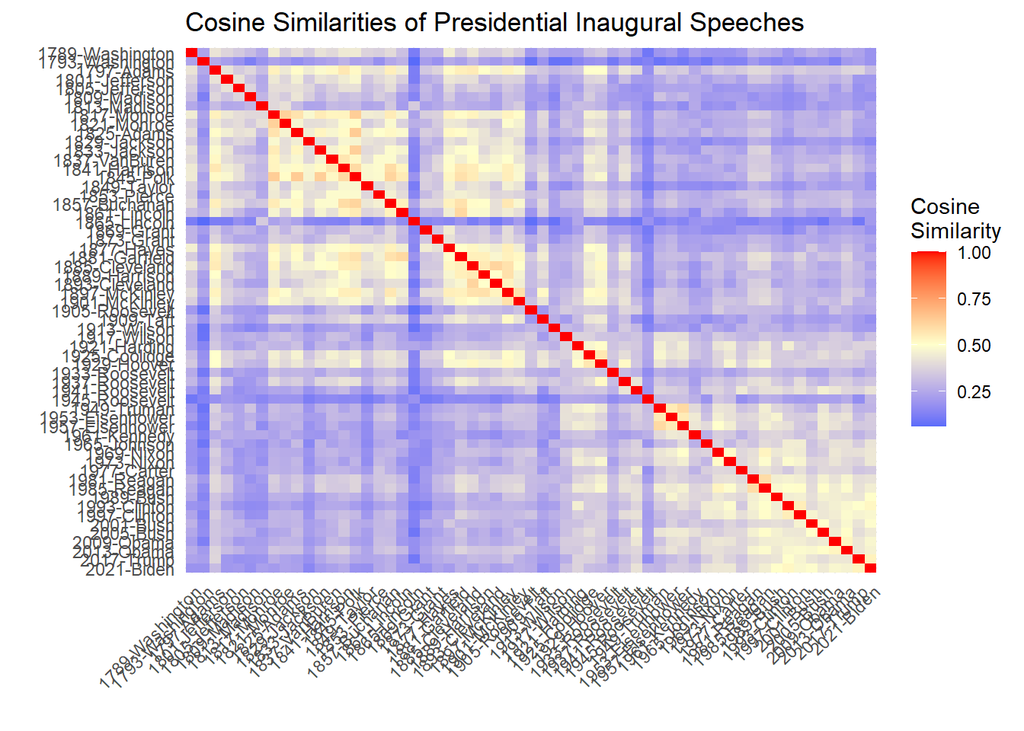

```r
all_speech_data <- data_corpus_inaugural %>% stack() %>% as_tibble()
colnames(all_speech_data) <- c("text", "title")

all_speeches <- all_speech_data %>% unnest_tokens(word, text) %>% anti_join(stop_words) %>% count(title, word)

all_tf_matrix <- all_speeches %>%
  bind_tf_idf(word, title, n) %>%
  cast_dtm(title, word, tf) %>%
  as.matrix()

# To calculate cosine similarity with matrices, normalize each column and multiply by transpose

for (i in 1:dim(all_tf_matrix)[1]) {
  all_tf_matrix[i,] <- normalize(all_tf_matrix[i,])
}


all.sims <- all_tf_matrix %*% t(all_tf_matrix)


data2 <- melt(all.sims)
colnames(data2) <- c("speech.i", "speech.j", "similarity")

ggplot(data2, aes(x = speech.j, y = speech.i, fill = similarity)) +
  geom_tile() +
  scale_fill_gradient2(low = "#075AFF",
                       mid = "#FFFFCC",
                       high = "#FF0000",
                       midpoint = 0.5,
                       space = "Lab",
                       name="Cosine\nSimilarity") +
  theme_minimal() +
  labs (x = "", y = "", title = "Cosine Similarities of Presidential Inaugural Speeches") +
  theme(axis.text.x = element_text(angle = 45, hjust = 1)) +
  ylim(rev(levels(data2$speech.i))) +
  xlim(levels(data2$speech.j))
```

The lighter yellowish reddish colors around the diagonal show that most inaugural speeches are similar to presidents of their time period.

This is the end of the hacker hour demo. Thanks for following along!

# Next steps!

Play around with the code yourself by analyzing different presidents’ speeches. Inaugural speeches can be pretty similar. Try doing a similar analysis on State of the Union speeches. I did some preprocessing below. See if you can implement tf-idf and cosine-similarity on these speeches. If you need help or want to share your analysis, message me on Discord (Archi#4892), LinkedIn, or email me at archiparekh23 at gmail dot com.

```r
# storing all speeches in temp files on my computer. View fp to see what it contains!
fp <- sotu_dir()

#Extracting speech titles from the file names
names <- fp %>% as_tibble() %>% mutate(speech_title = (value %>% str_extract(regex("/.*\\.")) %>% str_sub(2, -2)))

#Extracting speech text from each file and adding it to the tibble in the "text" column
for(i in 1:236){
  names$text[i] <- readLines(fp[i]) %>% paste(collapse = ' ')
}

#Renaming columns
colnames(names) <- c("file_name", "title", "text")

#Preprocessing
sotu_speeches <- names %>% unnest_tokens(word, text) %>% anti_join(stop_words) %>% count(title, word)

#Take a look at the sotu_speeches object. Use code from above to do some analysis!
```